## Assigment Two

### Sarah Liddle

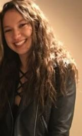

As for my goals post-graduation go, my dreams consist of two parts: writing and math. In general, I want to write novels and work in data science and statistics. Six months after graduation, I would hope to have a job working with data, though I’m open to what company it’s for. Five years later though, I hope to have experience working for a variety of places; I don’t want to just stay stuck in the first job I get. I want to explore different locations, companies, projects, etc. and use data science to learn about many different facets of our world that I’ve never explored before. On the writing side, I hope to be writing and publishing books in my free time–something along the style of Annie Dillard meets Stephen King, if such a thing could possibly exist.

This leads me to one question I would like to know the answer to that could be answered by analyzing data: are there any significant patterns in traits of people who historically read more horror novels? It could be an interesting way to find out more about audiences I may be writing towards in the future.

Thinking more in the long run about my goals, I admit that I don’t know the full potential of what I could do with data science, or what my greatest career accomplishment could be. I feel there’s so much unexplored territory that there is potential to use data to give a company information to make very great change in the world, and I hope I can be a part of that.

Given these goals, I hope to get all the essential tools for data science in this course that will be readily applicable to the real world. I have relatively little experience, and I’m hoping by the end of the course I feel confident in my ability to turn large data sets into knowledge that can be used.

And as for something that’s not included in the questions, I love animals. I have two dogs and two cats at home where I grew up, and my roommates and I just adopted a kitten this summer names Pants. Below, is a picture of one of my dogs, Max.

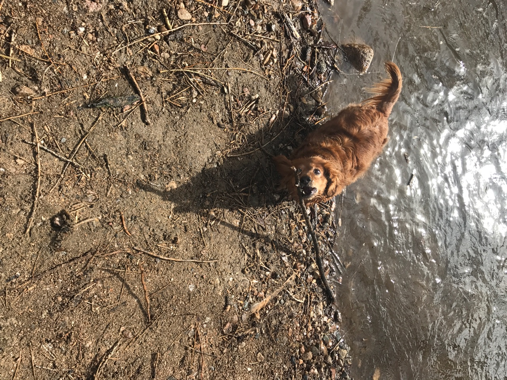